# Kruskal_Prim

Chunyan Xia

2020-12-20

```r
library(igraph)
```

## Definition of Minimum Spanning Tree

In all spanning trees of the connected network, the cost of all edges and the smallest spanning tree is called the minimum spanning tree.

## Prim Algorithm

This algorithm can be called “adding point method”, each iteration selects the point corresponding to the edge with the least cost and adds it to the minimum spanning tree. The algorithm starts from a certain vertex s and gradually grows to cover all vertices of the entire connected network.

### Step

3.Repeat the above steps until the minimum spanning tree has n-1 edges or n vertices.

### Function

```r
# Prim function
Prim <- function(vn, adjacency_matrix, myl){
  link_p <- function(x,y,w){#构建邻接矩阵与子节点矩阵
  adjacency_matrix_p[x,y]<<-w
  adjacency_matrix_p[y,x]<<-w
  }
  adjacency_matrix_p=matrix(0,vn,vn,byrow=T,dimnames=list(letters[1:vn],letters[1:vn]))
  a<-1
  visited <- c(0*(1:vn))
  visited[a]=1
  myg <- graph.adjacency(adjacency_matrix,mode = "undirected",weighted = TRUE)
  for(o in 1:vn-1 ){
    for(i in order(E(myg)$weight)){
      i=as.numeric(i)
      v1<-as.numeric(charToRaw(get.edgelist(myg)[i,1]))-as.numeric(charToRaw('a'))+1
      v2<-as.numeric(charToRaw(get.edgelist(myg)[i,2]))-as.numeric(charToRaw('a'))+1
      if(visited[v1]==1&&visited[v2]==0){
        link_p(v1,v2,E(myg)[i]$weight)
        visited[v2]=1
        E(myg)[i]$color="red"
        plot.igraph(myg,layout=myl,main="Prim",edge.label = E(myg)$weight)
        Sys.sleep(1)
        break
      }
      if(visited[v2]==1&&visited[v1]==0){
        link_p(v1,v2,E(myg)[i]$weight)
        visited[v1]=1
        E(myg)[i]$color="red"
        plot.igraph(myg,layout=myl,main="Prim",edge.label = E(myg)$weight)
        Sys.sleep(1)
        break
      }
    }
  }}
```

### Example

[figure not shown]

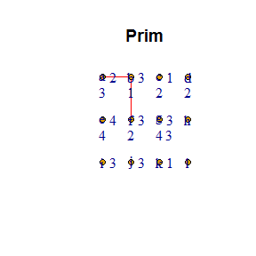

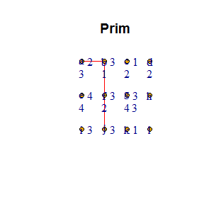

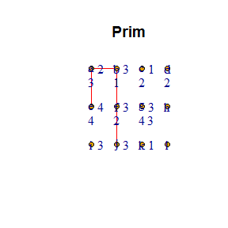

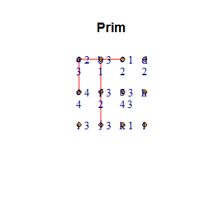

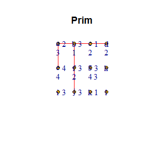

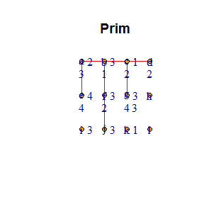

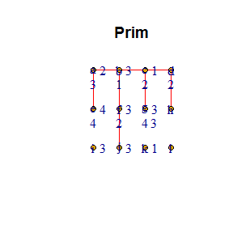

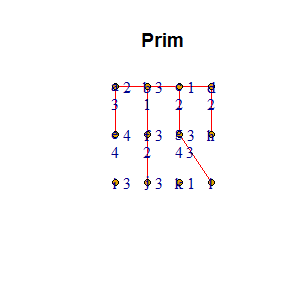

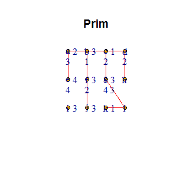

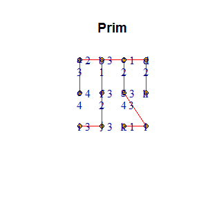

```r
vn <- 12
a <- c(0, 2, 0, 0, 3, 0, 0, 0, 0, 0, 0, 0,
 2, 0, 3, 0, 0, 1, 0, 0, 0, 0, 0, 0,
 0, 3, 0, 1, 0, 0, 2, 0, 0, 0, 0, 0,
 0, 0, 1, 0, 0, 0, 0, 2, 0, 0, 0, 0,
 3, 0, 0, 0, 0, 4, 0, 0, 4, 0, 0, 0,
 0, 1, 0, 0, 4, 0, 3, 0, 0, 2, 0, 0,
 0, 0, 2, 0, 0, 3, 0, 3, 0, 0, 4, 3,
 0, 0, 0, 2, 0, 0, 3, 0, 0, 0, 0, 0,
 0, 0, 0, 0, 4, 0, 0, 0, 0, 3, 0, 0,
 0, 0, 0, 0, 0, 2, 0, 0, 3, 0, 3, 0,
 0, 0, 0, 0, 0, 0, 4, 0, 0, 3, 0, 1,
 0, 0, 0, 0, 0, 0, 3, 0, 0, 0, 1, 0)
adjacency_matrix <- matrix(data = a, nrow = 12, ncol = 12, dimnames=list(letters[1:vn],letters[1:vn]))
b <- c(0,1,2,3,0,1,2,3,0,1,2,3,2,2,2,2,1,1,1,1,0,0,0,0)
myl <- matrix(data = b, nrow = 12, ncol = 2)
rm(a)


Prim(vn, adjacency_matrix, myl)
```

## Kruskal Algorithm

This algorithm can be called “addition method”, the initial minimum spanning tree edge number is 0, and each iteration selects a minimum cost edge that meets the condition and adds it to the minimum spanning tree edge set.

### Step

1. Sort all edges in the graph from smallest to largest cost;
2. Consider the n vertices in the graph as a forest composed of n independent trees;
3. Select edges from small to large according to the weight, and the two vertices ui and vi connected by the selected edges. ui and vi should belong to two different trees, and become an edge of the minimum spanning tree, and the two trees are merged into one tree.
4. Repeat Step 3 until all vertices are in a tree or there are n-1 edges.

### Function

```r
Kruskal <- function(vn, adjacency_matrix, myl){
  bindset <- function(x,y){
  same_set[x,y]<<-1
  same_set[y,x]<<-1
  for(i in 1:vn){
  i=as.numeric(i)
  if(same_set[y,i]==1&&i!=x&&i!=y&&same_set[x,i]==0) bindset(i,x)
  if(same_set[x,i]==1&&i!=y&&i!=x&&same_set[y,i]==0) bindset(i,y)
  }
}
  myg <- graph.adjacency(adjacency_matrix,mode = "undirected",weighted = TRUE)
  cnt<-0
  link_k <- function(x,y,w){#构建邻接矩阵与子节点矩阵
  adjacency_matrix_k[x,y]<<-w
  adjacency_matrix_k[y,x]<<-w
  }
  adjacency_matrix_k=matrix(0,vn,vn,byrow=T,dimnames=list(letters[1:vn],letters[1:vn])) #创建k子树邻接矩阵
  for(i in order(E(myg)$weight)){
    i=as.numeric(i)
    v1<-as.numeric(charToRaw(get.edgelist(myg)[i,1]))-as.numeric(charToRaw('a'))+1
    v2<-as.numeric(charToRaw(get.edgelist(myg)[i,2]))-as.numeric(charToRaw('a'))+1
    if(myset[v1]==0&&myset[v2]==0){
      setcnt<<-setcnt+1
      myset[v1]<<-setcnt
      myset[v2]<<-setcnt
      link_k(v1,v2,E(myg)[i]$weight)
      E(myg)[i]$color="red"
      plot.igraph(myg,layout=myl,main="Kruskal",edge.label = E(myg)$weight)
      #Sys.sleep(1)
      cnt=cnt+1
      if(cnt==vn-1) break
    }
    else{ if(myset[v1]==0||myset[v2]==0){
      if(myset[v2]==0) myset[v2]=myset[v1]
      else myset[v1]=myset[v2]
      link_k(v1,v2,E(myg)[i]$weight)
      E(myg)[i]$color="red"
      plot.igraph(myg,layout=myl,main="Kruskal",edge.label = E(myg)$weight)
      Sys.sleep(1)
      cnt=cnt+1
      if(cnt==vn-1) break
    }
    else if(same_set[myset[v1],myset[v2]]==0){
      bindset(myset[v1],myset[v2])
      link_k(v1,v2,E(myg)[i]$weight)
      E(myg)[i]$color="red"
      plot.igraph(myg,layout=myl,main="Kruskal",edge.label = E(myg)$weight)
      Sys.sleep(1)
      cnt=cnt+1
      if(cnt==vn-1) break
    }
    }
  }
}
```

### Example

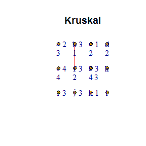

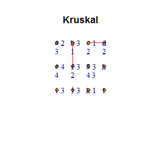

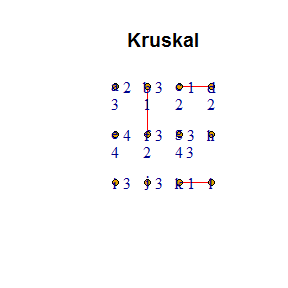

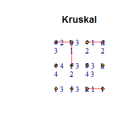

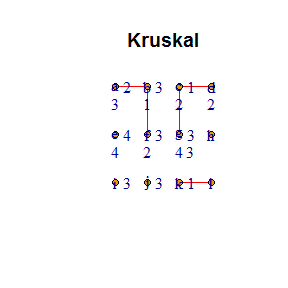

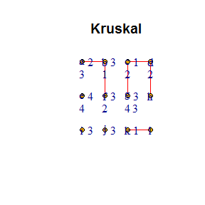

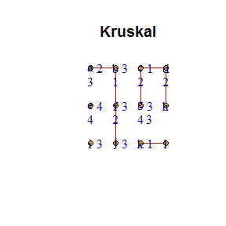

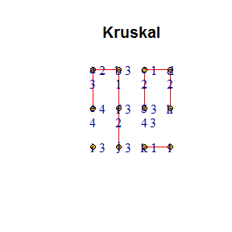

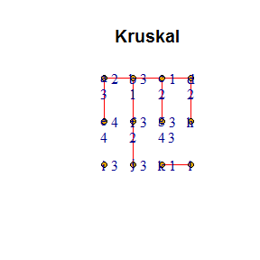

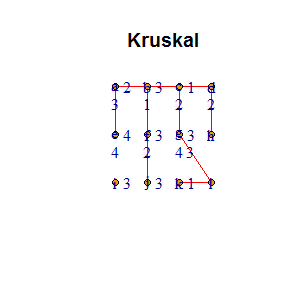

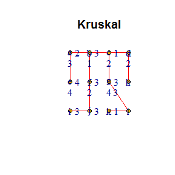

```r
vn <- 12
a <- c(0, 2, 0, 0, 3, 0, 0, 0, 0, 0, 0, 0,
 2, 0, 3, 0, 0, 1, 0, 0, 0, 0, 0, 0,
 0, 3, 0, 1, 0, 0, 2, 0, 0, 0, 0, 0,
 0, 0, 1, 0, 0, 0, 0, 2, 0, 0, 0, 0,
 3, 0, 0, 0, 0, 4, 0, 0, 4, 0, 0, 0,
 0, 1, 0, 0, 4, 0, 3, 0, 0, 2, 0, 0,
 0, 0, 2, 0, 0, 3, 0, 3, 0, 0, 4, 3,
 0, 0, 0, 2, 0, 0, 3, 0, 0, 0, 0, 0,
 0, 0, 0, 0, 4, 0, 0, 0, 0, 3, 0, 0,
 0, 0, 0, 0, 0, 2, 0, 0, 3, 0, 3, 0,
 0, 0, 0, 0, 0, 0, 4, 0, 0, 3, 0, 1,
 0, 0, 0, 0, 0, 0, 3, 0, 0, 0, 1, 0)
adjacency_matrix <- matrix(data = a, nrow = 12, ncol = 12, dimnames=list(letters[1:vn],letters[1:vn]))
b <- c(0,1,2,3,0,1,2,3,0,1,2,3,2,2,2,2,1,1,1,1,0,0,0,0)
myl <- matrix(data = b, nrow = 12, ncol = 2)
rm(a)
myset<-c(0*(1:vn))
same_set=matrix(0,vn,vn,byrow=T)
setcnt<-0
for(i in 1:vn) same_set[i,i]=1

Kruskal(vn, adjacency_matrix, myl)
```